# Pilot 2 Analysis

Josh Rule

6/23/2020

# 1 Introduction

This document analyzes data collected during a 2020-06-22 pilot of `v0.0.5` of the list-routines experiment. The analysis focuses on questions relevant to running a full-scale study.

# 2 Recommendations

- Regenerate concepts:
  - Generate new concepts for any concept predicted to have < 10% (20%?) mean accuracy, including any paired concepts if coming from the model-comparison dataset.
- Regenerate training data:
  - Assess example quality for dataset concepts
  - Pick the best of the 5 tested orderings for training sets scored “reorder”, according to my assessment of informativeness for human learners.
  - Update example constraints and generate new i/o pairs for training sets scored “resample”.
- Ask modelers to rerun any new training sets for the model-comparison problems.
- Adopt adaptive sampling based on some measure of performance variance.
- Maintain current levels of compensation, all else being equal.

# 3 Method

## 3.1 Participants

25 people participated in the experiment, hosted on Amazon Mechanical Turk via PsiTurk. Participant age ranged from 25.4yrs to 70.2yrs (median: 37yrs), with 12 males and 11 females (Figure 3.1).

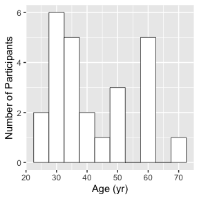

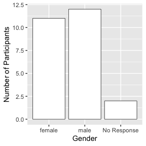

Figure 3.1: Histograms of participant age and gender, respectively.

## 3.2 Procedure

Participants began by reviewing a short set of instructions detailing the experimental design and completing a short quiz verifying their understanding of the task. They then completed 110 trials of the list-routines task—10 blocks of 11 trials each. The experiment concluded with a brief demographical survey.

In each trial, participants were shown an input list and asked to predict the output according to the rule they thought the computer was using to transform inputs into outputs. Each block used a different rule for transforming inputs into outputs. The 10 rules were selected randomly from a pool of 20 rules being tested, and their order was also randomized. The paradigm encouraged online learning: for trial N+1 of a block, participants saw the correct inputs and outputs from the previous N trials and were able to use them (and their past thinking about the function) to inform their prediction. At the conclusion of each block, participants were asked to describe in words the rule they thought the computer had been using.

Because each participant completed 10 blocks, we collected data from about 12 participants for each rule.

Participants were paid a flat fee of $7.50 for participating plus an additional $0.01 for each correct response, with a median compensation of $7.98 for a median 51.9min of work. Participants found the task difficult but engaging (Figure 3.2; Table 3.1).

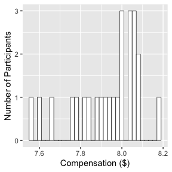

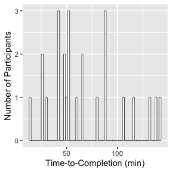

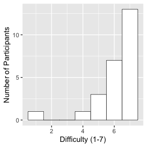

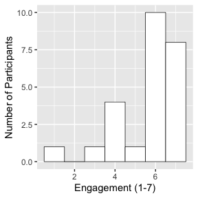

Figure 3.2: Histograms of participant ratings of difficulty and engagement, respectively.

Table 3.1: A statistical summary of participant demographics.

| Demographic | Min | 25% | Median | 75% | Max | # NA |
| --- | --- | --- | --- | --- | --- | --- |
| Compensation ($) | 7.56 | 7.85 | 7.98 | 8.05 | 8.18 | 0 |
| Time-to-completion (min) | 13.38 | 41.70 | 51.92 | 88.72 | 142.87 | 0 |
| Difficulty (1–7) | 1.00 | 6.00 | 7.00 | 7.00 | 7.00 | 0 |
| Engagement (1–7) | 1.00 | 5.00 | 6.00 | 7.00 | 7.00 | 0 |

## 3.3 Materials

Table 3.2 describes each function.

[output not shown]

# 4 Results

## 4.1 Task difficulty in the pilot

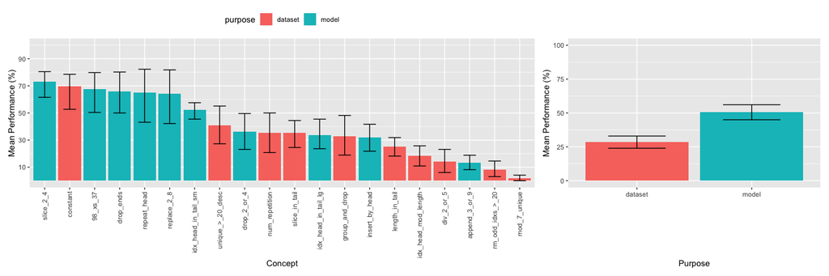

Figure 4.1: (Left): Mean accuracy (y-axis) on each concept (x-axis); (Right): Mean per-concept accuracy (y-axis) by purpose (x-axis). Bars are bootstrapped 95% CIs.

Several of our predictions focused on task difficulty. We predicted that:

1. For most model-comparison tasks, most participants will learn that tasks.
2. Dataset task learnability would be significantly lower than model-comparison task learnability
3. For most dataset tasks, a significant number of participants will learn that task.

I also grouped—post-hoc but without consulting the results—the specific functions involved in the pilot as follows, from easiest to hardest:

1. `constant`, `slice_2_4`, `replace_2_8`, `repeat_head`, `drop_ends`, `98_xs_37`
2. `slice_in_tail`
3. `insert_by_head`, `unique_>_20_desc`, `group_and_drop`, `div_2_or_5`
4. `idx_head_mod_length`, `idx_head_in_tail_sm`, `idx_head_in_tail_lg`
5. `drop_2_or_4`, `append_3_or_9`, `num_repetitions`, `length_in_tail`, `rm_odd_idxs_>_20`, `mod_7_unique`

Group 1 uses the same simple rule every time, without conditions or reasoning about values in the list. Group 2 requires reasoning about the value of items in the list. Group 3 chains multiple operations together, with `div_2_or_5` perhaps being the hardest (you have to figure out what condition separates dividing by 2 from dividing by 5). Group 4 boils a list down to a single number, so the amount of information received on each trial is relatively low. That number, however, is in the list, so the structure of the list can provide hints about the rule. Group 5 either boils down to a single number that isn’t in the list or involves complex conditions.

Figure 4.1.left also tells us the relative difficulty of each concept. There seem to be roughly four groups:

1. easy: `slice_2_4`, `constant`, `98_xs_37`, `drop_ends`, `replace_2_8`, and `repeat_head`
2. moderately easy: `idx_head_in_tail_sm`, `unique_>_20_desc`, `drop_2_or_4`, `num_repetition`, `slice_in_tail`, `idx_head_in_tail_lg`, `group_and_drop`, and `insert_by_head`
3. moderately_hard: `length_in_tail`, `idx_head_mod_length`, `div_2_or_5`, `append_3_or_9`, and `rm_odd_idxs_>_20`
4. hard: `mod_7_unique` (the only concept where accuracy isn’t statistically different from 0)

Compared to my predictions: `idx_head_in_tail_sm` and `num_repetitions` are much easier; `idx_head_in_tail_lg` is moderately easier; `slice_in_tail` and `idx_head_mod_length` are moderately harder; and `div_2_or_5` is much harder.

Speculating on why we see these deviations from my predictions:

- `div_2_or_5`: the comments suggest that people never realized that sometimes you divide by 2 and sometimes by 5. This could be because integer division is an odd concept for people, something they learned but not high in their prior. Also, the eveness/oddness of the length of the list might be an odd condition to consider. In any case, no one articulated the two cases clearly, and no one articulated the condition deciding between cases.
- `idx_head_mod_length`: the comments suggest that people knew it had to do with placement in the list based on the head, but they didn’t know what to do for large heads. Using the least significant digit was a common hypothesis, but cycling around the list or computing the remainder/modulus was not mentioned. Division-based concepts appear difficult.
- `slice_in_tail`: my hypothesis is that this one fails because the examples are bad (e.g. `[8, 32, 9, 54] -> [9, 54]` removes no slice, because the slice doesn’t start until index 9, and the endpoint is much higher than 15. 8 of 11 trials are like this.). This is a dataset task, so we could regenerate these trials with additional constraints.
- `num_repetitions`: the concept of the number of repetitions was simply more obvious to people than I expected.
- `idx_head_in_tail_sm` and `idx_head_in_tail_lg`: in 7/11 and 4/11 trials, respectively, you could just guess the last number and be right. This is another case of bad data, but these are model-comparison tasks. In reality, just 1–3 people appear to have acquired the general rule for each of these.

Figure 4.1.right summarizes per-function accuracy between dataset and model-comparison tasks, confirming that model-comparison tasks are significantly easier.

## 4.2 Predicting task difficulty

```
##
## Call:
## lm(formula = mu ~ length, data = data)
##
## Residuals:
##      Min       1Q   Median       3Q      Max
## -0.37393 -0.13897 -0.05664  0.17775  0.49151
##
## Coefficients:
##              Estimate Std. Error t value Pr(>|t|)
## (Intercept)  0.534381   0.115975   4.608 0.000291 ***
## length      -0.007831   0.005557  -1.409 0.177864
## ---
## Signif. codes:  0 '***' 0.001 '**' 0.01 '*' 0.05 '.' 0.1 ' ' 1
##
## Residual standard error: 0.2278 on 16 degrees of freedom
## Multiple R-squared:  0.1104, Adjusted R-squared:  0.05484
## F-statistic: 1.986 on 1 and 16 DF,  p-value: 0.1779
```

```
##
## Call:
## lm(formula = mu ~ depth + length + visible + semi, data = data)
##
## Residuals:
##       Min        1Q    Median        3Q       Max
## -0.125282 -0.033068 -0.001846  0.030187  0.091347
##
## Coefficients:
##              Estimate Std. Error t value Pr(>|t|)
## (Intercept)  0.621022   0.043125  14.401 2.28e-09 ***
## depth        0.040047   0.014033   2.854   0.0136 *
## length      -0.047737   0.005672  -8.417 1.28e-06 ***
## visible      0.075439   0.006113  12.341 1.49e-08 ***
## semi         0.062625   0.009035   6.931 1.04e-05 ***
## ---
## Signif. codes:  0 '***' 0.001 '**' 0.01 '*' 0.05 '.' 0.1 ' ' 1
##
## Residual standard error: 0.06355 on 13 degrees of freedom
## Multiple R-squared:  0.9437, Adjusted R-squared:  0.9264
## F-statistic: 54.53 on 4 and 13 DF,  p-value: 5.36e-08
```

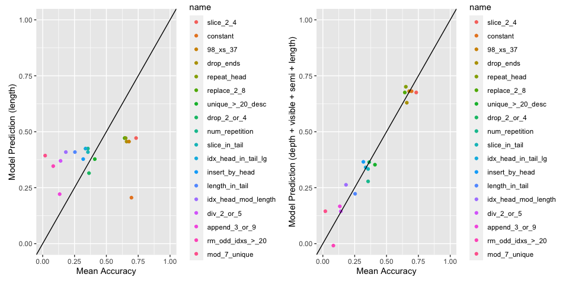

Figure 4.2: Length-based predictive models of difficulty. (Left): Linear regression predictions of mean acuracy based solely on concept length in the DSL; (Right): Linear regression predictions of mean acuracy based on concept length in the DSL, adjusted for the amount of visible and semi-visible information.

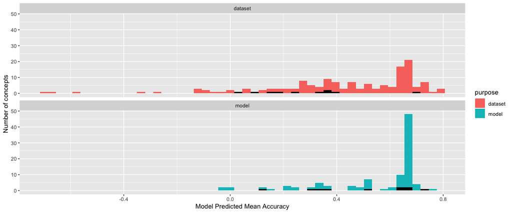

We’d like to be able to predict task difficulty, so we can decide whether our concepts are too easy, too difficult, or sitting in the sweet spot for human learning. Let’s start with a simple model based on the prior probability of each concept in the DSL. Over all 250 problems, negative log prior and length in the DSL are strongly correlated ($\rho =$ 0.9953368. Length is also much easier to compute and in the same units as some of the other data I’ve collected about visibility, so we’ll use length in what follows. Figure 4.2.left shows the relationship between mean accuracy and length over our pilot concepts. The correlation is terrible because of some notable outliters. We can improve it by adjusting for two additional kinds of information about each program: its depth, and the amount of program structure visible in the final output. Figure 4.2.right shows the impact of these changes on the model’s predictiveness.

We can apply this improved model to the 230 untested concepts to get some indication for how difficult they are likely to be. Figure 4.3 plots these predictions and suggests that while we have some extremely difficult that are probably worth redefining, we have a pretty nice distribution over concept difficulty. If anything, we may want to make those extremely difficult concepts fairly moderate to fill in the distribution. If, for example, we decide to replace anything with a predicted accuracy below 10%, Table 4.1 shows what needs to be replaced.

Table 4.1: Predicted accuracies (Accuracy) for the concepts with predicted accuracy < 10%. Note that only 4 are from the model-comparison (i.e. id starts with “m”).

| Id | Accuracy | Program |
| --- | --- | --- |
| d078 | -0.690 | `(lambda (fold (lambda (lambda (if (is_even (second $0)) (append $1 (first $0)) $1))) empty (zip (droplast 1 $0) (drop 1 $0))))` |
| d122 | -0.667 | `(lambda (filteri (lambda (lambda (is_odd $1))) (map (lambda (- (max $0) (min $0))) (zip (droplast 1 $0) (drop 1 $0)))))` |
| d130 | -0.592 | `(lambda (if (&gt; (min $0) (- (max $0) (min $0))) (range (min $0) 2 (max $0)) (range 0 2 (min $0))))` |
| d121 | -0.341 | `(lambda (singleton (max (cons (sum (filteri (lambda (lambda (is_even $1))) $0)) (singleton (sum (filteri (lambda (lambda (is_odd $1))) $0)))))))` |
| d046 | -0.262 | `(lambda (map (lambda (- (max $0) (min $0))) (zip (droplast 1 $0) (drop 1 $0))))` |
| d097 | -0.137 | `(lambda (filter (lambda (and (&gt; 50 $0) (&gt; (- $0 (min $1)) 10))) $0))` |
| d095 | -0.129 | `(lambda (flatten (sort (lambda (% (first $0) 4)) (group (lambda (% $0 4)) $0))))` |
| d123 | -0.110 | `(lambda (map (lambda (sum (filter (lambda (== (% $0 $1) 0)) $1))) (range 1 1 10)))` |
| d092 | -0.087 | `(lambda (map (lambda (if (&lt; $0 50) (% $0 10) (/ $0 10))) $0))` |
| d094 | -0.079 | `(lambda (filter (lambda (is_in $1 $0)) (range (min $0) 2 (max $0))))` |
| d093 | -0.046 | `(lambda (if (&lt; (length $0) 5) $0 (drop 5 (sort (lambda $0) $0))))` |
| d079 | -0.041 | `(lambda (fold (lambda (lambda (append (reverse $1) $0))) empty (reverse (sort (lambda $0) $0))))` |
| m035 | -0.026 | `(lambda (if (or (== (second $0) (nth 4 $0)) (&gt; (length $0) 7)) (swap 1 4 $0) (swap 2 3 $0)))` |
| m088 | -0.026 | `(lambda (if (or (== (second $0) (nth 4 $0)) (&gt; (length $0) 7)) (swap 1 4 $0) (swap 2 3 $0)))` |
| d085 | -0.009 | `(lambda (filteri (lambda (lambda (or (== (% $1 2) 0) (&gt; 20 $0)))) $0))` |
| d116 | 0.004 | `(lambda (flatten (reverse (sort (lambda (/ (first $0) 10)) (group (lambda (/ $0 10)) $0)))))` |
| m039 | 0.009 | `(lambda ((lambda (if (&gt; (length $0) 5) (append $0 3) $0)) ((lambda (if (== (second $0) (third $0)) (append $0 9) $0)) $0)))` |
| m076 | 0.009 | `(lambda (map (lambda (- $0 3)) (filter (lambda (&gt; $0 5)) $0)))` |
| d108 | 0.024 | `(lambda (map (lambda (- (max $0) (min $0))) (zip $0 (reverse $0))))` |
| d126 | 0.052 | `(lambda (drop (/ (first $0) 10) (droplast (/ (last $0) 10) $0)))` |
| d080 | 0.054 | `(lambda (fold (lambda (lambda (append (reverse $1) $0))) empty (sort (lambda $0) $0)))` |
| d138 | 0.064 | `(lambda (singleton (sum (filter (== 1) (map length (group (lambda $0) $0))))))` |
| d103 | 0.097 | `(lambda (find (lambda (and (&gt; $0 20) (&lt; $0 50))) $0))` |

**Note**: We wondered how many categories we needed for dealing with the visibility of a node in the program, where by visibility we mean how directly its impact can be seen in a given input/output pair. The model coefficients for `visible` and `semi` (two non-zero levels of visiblity), however, are pretty similar. This could mean that I wasn’t consistent in assigning nodes to these two categories, that these categories aren’t that different from one another, or that we need a more fine-grained method for assigning visibility scores to nodes.

**NOTE**: I exclude `idx_head_in_tail_sm` and `group_and_drop` from these analyses because I think the data more strongly reflects extremely bad examples than the difficulty of the concepts.

## 4.3 Example quality

I haven’t yet analyzed the example quality for the dataset concepts.

I have done analyzed the model-comparison concepts, assigning each to 1 of 3 categories: “good” (examples are good), “order” (examples are okay so long as we change the order), or “resample” (examples need to be resampled). We’ve run the models on 5 orderings of the same trials, so “order” just suggests selecting a better trial ordering from these 5 for the human experiment—we won’t need to rerun the models.

Of the 100 concepts, 57 scored “good”, 33 scored “order”, and 10 scored “resample”. For those scoring “resample”, Table 4.2 shows the predicted accuracies. For the four concepts with the lowest predicted accuracies, it might make sense to generate new concepts altogether.

Table 4.2: Predicted accuracies (Accuracy) for the model-comparison concepts (Id; Concept) I’ve assessed as needing new training data.

| Id | Predicted Accuracy | Program |
| --- | --- | --- |
| m078 | 0.580 | `(lambda (singleton (max $0)))` |
| m060 | 0.513 | `(lambda (swap 3 1 (replace 4 4 (cut_idx 6 (take 7 $0)))))` |
| m005 | 0.341 | `(lambda (singleton (nth (first $0) (drop 1 $0))))` |
| m015 | 0.334 | `(lambda (slice (first $0) (second $0) (drop 2 $0)))` |
| m027 | 0.290 | `(lambda (cut_idx (if (== (first $0) (third $0)) 3 2) $0))` |
| m002 | 0.253 | `(lambda (if (&gt; 3 (length $0)) empty (singleton (third $0))))` |
| m040 | 0.167 | `(lambda ((lambda (if (&gt; (third $0) 3) (append $0 3) $0)) ((lambda (if (== (second $0) 9) (append $0 9) $0)) $0)))` |
| m036 | 0.132 | `(lambda (if (or (== (second $0) 7) (&gt; (nth 4 $0) 7)) (swap 1 4 $0) (swap 2 3 $0)))` |
| m089 | 0.132 | `(lambda (if (or (== (second $0) 7) (&gt; (nth 4 $0) 7)) (swap 1 4 $0) (swap 2 3 $0)))` |
| m039 | 0.009 | `(lambda ((lambda (if (&gt; (length $0) 5) (append $0 3) $0)) ((lambda (if (== (second $0) (third $0)) (append $0 9) $0)) $0)))` |

## 4.4 Learning is not just 3-in-a-row

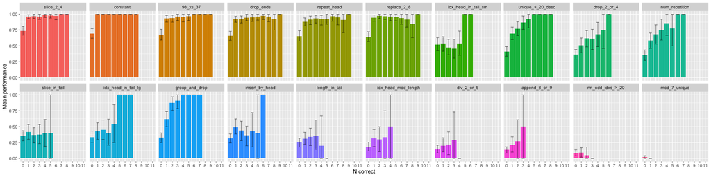

Figure 4.4: Probability of correct response (y-axis) after N correct responses (x-axis) by concept (subplots). Errors bars are bootstrapped 95% CI.

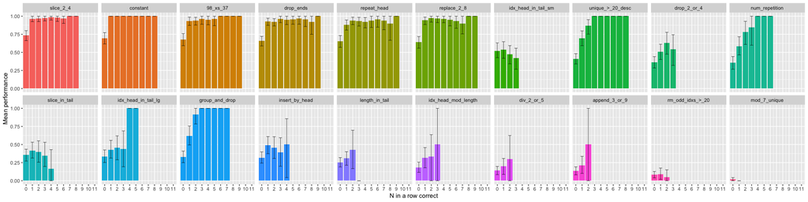

Figure 4.5: Probability of correct response (y-axis) after giving N consecutive correct responses (x-axis) by concept (subplots). Errors bars are bootstrapped 95% CI.

We assess function learning as correctly responding to three trials in a row. Figures 4.4–4.5 show that we likely need a better way of identifying when participants learn each concept. 3-in-a-row appears to work well for easy and some moderate concepts, but for other moderate concepts and for difficult concepts, it appears less predictive. It might be the case for several of the harder concepts that learners acquire a portion of the concept that allows them to correctly respond to some trials but not others.

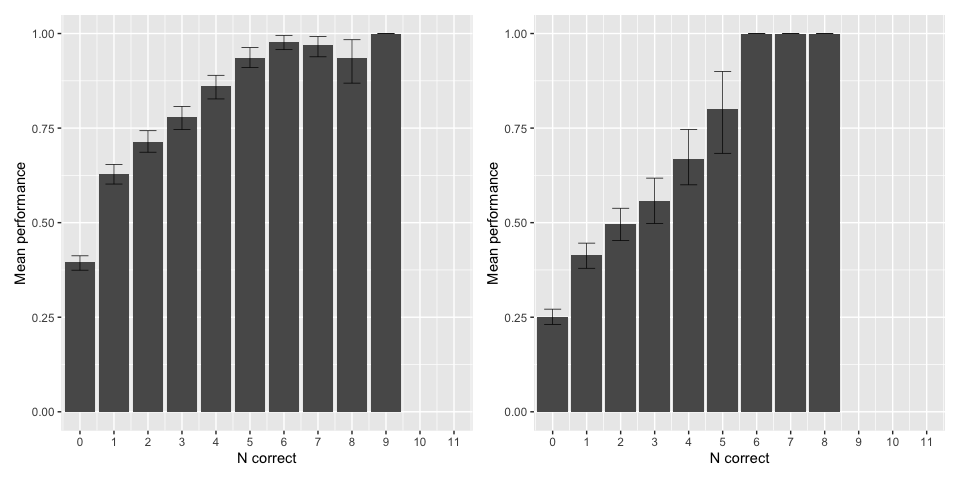

Figure 4.6: Similar to 4.4. (Left): aggregating over all concepts; (Right): aggregating over all but the top 7 concepts.

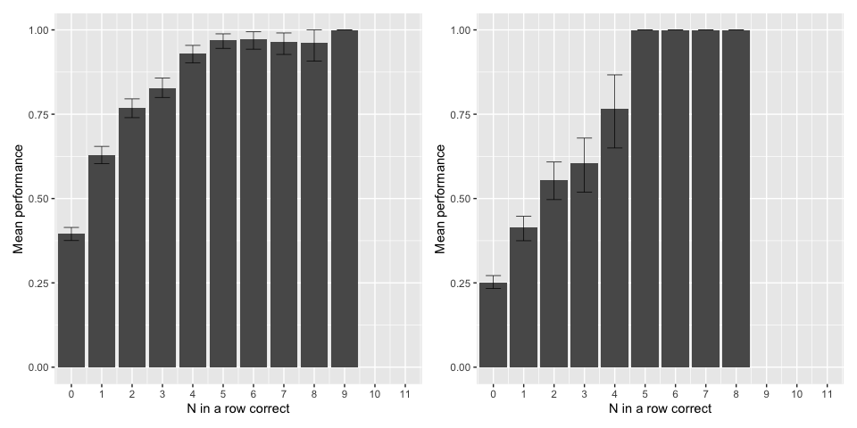

Figure 4.7: Similar to 4.5. (Left): aggregating over all concepts; (Right): aggregating over all but the top 7 concepts.

We have relatively little data for large numbers of correct trials on the difficult concepts, so to make the point more clearly, we aggregate over concepts. Figures 4.6–4.7 show that using either 3 correct or 3-in-a-row correct appears like a good strategy when aggregating over all concepts (left subplots) but looks much less convincing after filtering out the easiest concepts (right subplots).

Figures 4.4–4.7 also show that there’s very little difference between getting N overall and getting N-in-a-row. Neither is a particularly good metric for having learned a concept given the limited number of trials available.

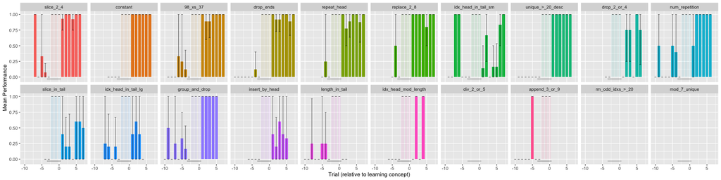

Figure 4.8: Backward learning curves in the style of Bower & Trabasso. Mean performance (y-axis) for each trial relative to the first third consecutive correct response (x-axis) by concept (subplots). Error bars are bootstrapped 95% CIs. The underlined portion is constant across all plots (the leadup to three-in-a-row) and so deemphasized for clarity.

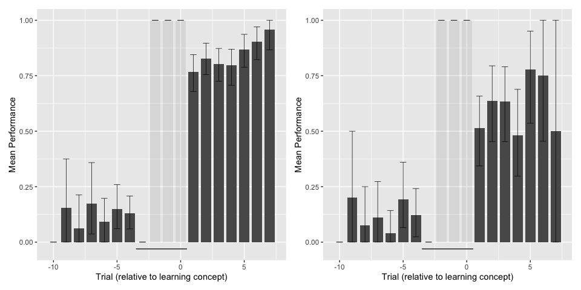

Figure 4.9: Backward learning curves in the style of Bower & Trabasso similar to Figure 4.8. (Left): aggregating over all concepts; (Right): aggregating over all but the top seven concepts (i.e. dropping the easy concepts).

We can repeat the analysis using a backward learning curve, but there’s not enough data/concept to draw clear conclusions (Figure 4.8. Collapsing over concepts in Figure 4.9 reinforces the earlier plots in this section: there’s certainly a difference in performance after getting 3-in-a-row, but that doesn’t imply that performance will be at ceiling.

## 4.5 Individual differences

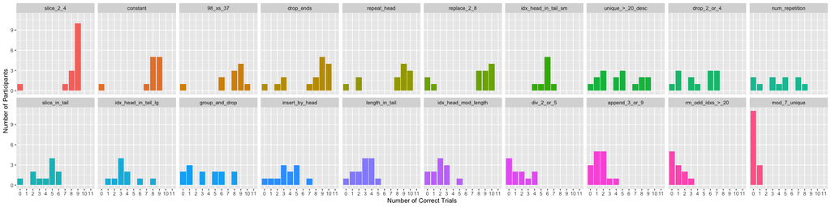

Figure 4.10: Number of subjects (y-axis) for each possible number of correct responses (x-axis) by concept (colored curves).

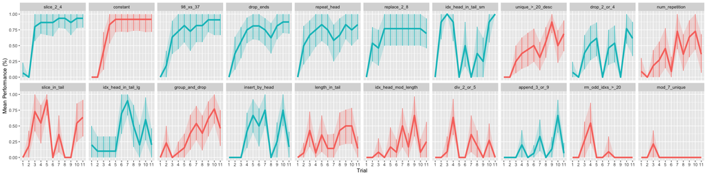

Figure 4.11: Mean performance (y-axis) by trial (x-axis) by concept (colored curves), with bootstrapped 95% CI (shaded regions).

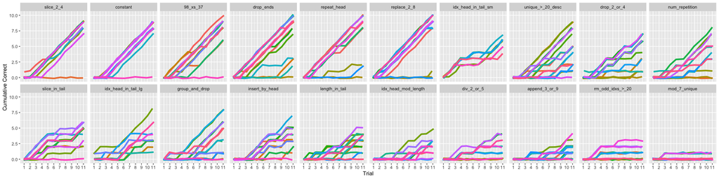

If we don’t use 3-in-a-row, we’ll need some other metric for deciding when to continue collecting data from additional participants. I don’t have the answer, but I think we may want to look at our understanding of inter-participant/intra-concept variance, how many patterns of response do we see within a concept?

Figures 4.10–4.12 show a few ways of looking at that. For easy and difficult concepts, the variance in these plots is fairly low—most people are doing roughly the same thing. For moderately difficult concepts, however, the distributions are dispersed. People appear to master the concept at different rates, with some never doing so. Learning curves which average over all participants may be relatively informative for easy and hard concepts but are probably not the best way to see what’s happening for intermediate concepts. We want a better measure of this variance.

## 4.6 Time per block

Table 4.3: A statistical summary of time-to-completion by block. All times reported in minutes (min).

| Block | Min | 25% | Median | 75% | Max |
| --- | --- | --- | --- | --- | --- |
| Instructions | 1.04 | 1.94 | 3.29 | 6.06 | 56.92 |
| Quiz | 0.14 | 0.37 | 0.58 | 0.84 | 37.90 |
| 1 | 1.84 | 4.07 | 6.34 | 9.72 | 57.32 |
| 2 | 1.05 | 2.98 | 3.48 | 6.37 | 76.76 |
| 3 | 1.17 | 2.37 | 4.06 | 6.95 | 95.21 |
| 4 | 1.11 | 2.70 | 3.62 | 6.56 | 17.89 |
| 5 | 1.16 | 1.59 | 3.39 | 4.44 | 12.72 |
| 6 | 0.72 | 2.21 | 3.71 | 5.01 | 12.06 |
| 7 | 0.90 | 2.35 | 3.32 | 5.69 | 7.69 |
| 8 | 1.05 | 2.03 | 3.13 | 4.43 | 15.86 |
| 9 | 0.77 | 2.06 | 3.12 | 4.98 | 10.82 |
| 10 | 0.85 | 1.69 | 3.14 | 4.60 | 14.92 |
| Survey | 0.30 | 0.57 | 0.70 | 1.05 | 1.65 |

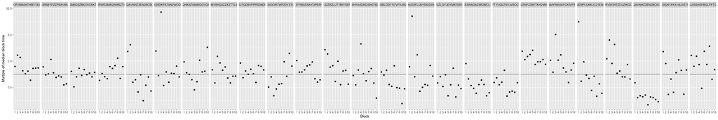

Figure 4.13: Deviations from the median block time (y-axis) by block (x-axis) by participant (subplots). Most participants have $\ge$ 1 substantially longer block.

We predicted that subjects would on average take 45min to complete the experiment, taking 4min to review the instructions and pass the quiz, just over 5min for the first block, just under 4min per subsequent block, and 1min for the closing survey. Table 4.3 shows that people were slightly slower on the first block but notably faster on subsequent blocks, such that the sum of the median time per block is less than our initial estimate. The median total time, however, is higher than our initial estimate; Figure 4.13 shows that most participants had at least one block which took them substantially longer than average.

## 4.7 Participant verbal responses

Below are participant responses to the query at the end of each block, grouped by function and sorted by participant performance (best first), as well as participants comments about the HIT and their programming experience. Notably, while a few participants had significant computer science backgrounds, most reported having no meaningful programming experience.

### 1

`slice_2_4`: `(lambda (slice 2 4 $0))`

| Response |
| --- |
| use the 2nd, third, and fourth number in the string in order they came |
| What are the 2nd, 3rd and 4th numbers in the list |
| Use the 2nd, 3rd and 4th numbers from the list |
| The second, third, and fourth numbers in the sequence |
| Record the second, third and fourth number of the sequence. |
| The second, third and fourth number |
| list the second through fourth digits in the series |
| 2nd, 3rd, and 4th numbers |
| Keep the 2, 3, and 4th digit |
| NONE |
| 2nd 3rd and 4th number |
| take the second third and fourth number and discard the rest |
| FIRST NUMBER ELIMINATE NEXT THREE NUMBER ENTER |
| input the 2nd to 4th only |
| put 2nd , 3rd and 4th numbers down |

### 2

`constant`: `(lambda (cons 11 (cons 19 (cons 24 (cons 33 (cons 42 (cons 5 (cons 82 (cons 0 (cons 64 (cons 9 empty)))))))))))`

| Response |
| --- |
| The numbers 11, 19, 24, 33, 42, 5, 82, 0, 64, 9 are the answer for all lists |
| Use the answer to question 1 for the rest of the questions.? |
| The answer was always 11,19,24,33,42,5,82,0,64,9 regardless of the input set |
| The numbers: 11, 19, 24, 33, 42, 5, 82, 0, 64, 9 are used for all of the lists |
| input the same numbers |
| I’m not certain where the computer generated this rule from, but it just repeated itself, so I went with it. |
| Output 11,19,24,33,42,5,82,0,64,9 no matter what the numbers are |
| same solution |
| What was the answer before this question? |
| NONE |
| just enter the answer no matter what list pops up |
| not sure |

### 3

`98_xs_37`: `(lambda (cons 98 (append $0 37)))`

| Response |
| --- |
| Put the number 98 at the beginning of the string and the number 37 at the end of the string |
| put 98 at the beginning of the list and 37 at the end of the list |
| Add 98 at the beginning of the list and 37 at the end. |
| add 98 at the beginning and 37 at the end |
| Add 98 to the beginning of the list and 37 at the end. |
| ad 98 in front, 37 at the end |
| Add 98 at the beginning and 37 at the end. |
| adding 98 at the start and ending with 37 |
| put 98 at first place and 37 at last place |
| start with 98, copy sequence, end with 37 |
| not sure |

### 4

`drop_ends`: `(lambda (drop 1 (droplast 1 $0)))`

| Response |
| --- |
| delete the first and last number in the sequence |
| omit first and last numbers |
| Drop the first digit and the last digit |
| Leave off the first and last number. |
| put all numbers but the first and last ones |
| remove the first and last digits |
| I believe alot of fear around technology / computers currently, is deeply entrenched in something very simple: people’s fear of other people. Although we “Other-ize |
| Remove the first and last numbers |
| remove the first and last numbers from the sequence |
| drop the first number and the last number |
| Remove the first and last number from the list |
| List the numbers that are between the first and last number of the sequence. |
| Choose everything number expect the first and last number in the list |
| drop the first and the last |
| Ah, the rule was chopping off the first and last number and entering in the middle combo. |
| ending numbers at random |

### 5

`repeat_head`: `(lambda (cons (first $0) $0))`

| Response |
| --- |
| put the first number twice and then copy the rest as they are listed |
| Add the first number in the sequence twice. |
| The first number is repeated at the beginning of the list |
| Repeat the first number of the list |
| repeat the first number |
| NONE |
| repeat the first number at the beginning once |
| Multiply the first number in the string by 1 and put that number at the beginning of the string |
| repeat the first digit in the series |
| the second number changed, others stayed the same |
| n/a |
| counting by 7 i think |

### 6

`replace_2_8`: `(lambda (replace 2 8 $0))`

| Response |
| --- |
| Change the second number in the list to 8 |
| Just replace the second digit with 8, regardless |
| Change the second number to an 8. |
| Transform the second number into 8 and then list the whole sequence |
| Change the second number to eight |
| SCOND NUMBER IS EIGHT ALWAYS |
| change the second number to 8 |
| Replace the 2nd number with the number 8. All else is the same |
| change the second number to eight |
| change the second number to 8 |
| The second number changed, others remained the same |
| count by 4 |
| add next |

### 7

`idx_head_in_tail_sm`: `(lambda (singleton (nth (first $0) (drop 1 $0))))`

| Response |
| --- |
| take the fourth number |
| last number and number before that |
| The only rule I can think it may be is “pick the first number that’s either divisible by, or can be divided into, the first number on the list”? |
| Skip the first number, starting at the second number, count the numbers to the value of the first number and choose the one in the sequence that matches that value (ie. if you have 2,4,7,8, you take t… |
| last number unless there is a pair in sequence, then first after pair |
| it just seemed to be going back in the number selection that was already available, by random amounts. |
| I don’t know the rule here. I thought it was just repeating the last number, but that isn’t so. |
| Pick the second to last number in the list |
| Choose the median number |
| Last number applies |
| last number in the sequence |
| Which number is the 3rd from last in the list |
| What is the 5th number if list is more than 6 numbers or the 3rd if less |
| I genuinely do not know. I thought it might be the second to last number, but that was not it |
| I have absolutely no idea |
| I have no idea with this one. |
| NONE |
| Get the number that is the first number plus one in. |

### 8

`unique_>_20_desc`: `(lambda (reverse (sort (lambda $0) (unique (filter (lambda (< 20 $0)) $0)))))`

| Response |
| --- |
| Place all numbers over 10 from highest to lowest |
| All double digit numbers in descending order, no repeats |
| List each double digit number once, regardless of how many times it appears, in descending order |
| Place numbers highest to lowest above 10 |
| Record two digit numbers only, and write them in descending order. |
| throw out any number under 10. If number is in the string twice only put one, and arrange the string in descending order |
| the rule removed small numbers and counted the large numbers in order |
| DECENDING ORDER ONLY TWO DIGIT NUMBERS |
| two digit numbers in descending order |
| only include 2 digit numbers, don’t repeat, descending order |
| put double digits entries in order shown |
| remove all numbers below 20 and remove any repeat numbers |
| reccuring numbers are chosen |
| No clue, can’t figure out or even guess |
| n/a |
| no idea |

### 9

`drop_2_or_4`: `(lambda (drop (if (and (== (second $0) 0) (> (first $0) 5)) 2 4) $0))`

| Response |
| --- |
| Remove first 4 numbers from list unless 0 is the second number, then remove first 2 only |
| It was to drop the first 4 digits, but there seemed to be some kind of exception to only drop the first two in some circumstances, but I didn’t figure out what it was |
| remove the first 4 digits |
| It seems like the rule is to eliminate the first four numbers on the list, but in two instances (where there were a longer amount of numbers) this did not work…so I’m perplexed. |
| Delete first 4 numbers unless one of the numbers is zero, in that case start list with the number following the zero |
| ELIMINATE FIRST FOUR NUMBERS |
| Record the last portion of numbers? |
| I was wrong but thought that depended on quantity of numbers in list: 5 - report last one, 6 report last 2, etc |
| remove the first four numbers then list the rest unchanged |
| Which numbers come at the end of this list |
| Some of the last numbers, but no idea what was the logic of how many of the numbers |
| the rule here seemed to skip a certain amount of the first numbers in the sequences. I couldn’t determine how many, though |
| counting by 3 |

### 10

`num_repetition`: `(lambda (singleton (sum (filter (< 1) (map length (group (lambda $0) $0))))))`

| Response |
| --- |
| The number of numbers that repeat at least once |
| The number of numbers that are repeated. |
| How many numbers are repeated in the list |
| the rule counted the number duplicates, I think |
| Count the duplicates individually |
| count the repeating numbers |
| n/a |
| count of repetitions |
| absolutely no idea, didn’t make sense to me |
| count the numbers shown and put that amount down |
| 1 digit number |

### 11

`slice_in_tail`: `(lambda (cut_slice (first $0) (second $0) (drop 2 $0)))`

| Response |
| --- |
| ELIMINATE FIRST TWO NUMBERS |
| What are the numbers after the first two in the list. This did not hold true on 3 of them though. |
| Record the digits after the second digit, only if there are possibly no doubles? |
| Sometimes remove the first two numbers from the list - but there’s a secondary rule I couldn’t work out |
| For most it seemed all digits after the second number counted, but for some it seemed to reduce the solution set to just a few, no idea why |
| Remove the first two numbers, with two unknown rules |
| cut the first two and do something else after |
| remove the first 2 |
| What are the numbers that follow the first two numbers in the list |
| Again, although the rule isn’t supposed to change midway, it seems like it does. It seemed like the rule might be “eliminate the first two numbers and keep the rest” but this didn’t work with some. So… |
| I don’t know |

### 12

`idx_head_in_tail_lg`: `(lambda (singleton (nth (first $0) (drop 1 $0))))`

| Response |
| --- |
| The only rule I can think it may be is “pick the first number that’s either divisible by, or can be divided into, the first number on the list”? |
| Skip the first number, starting at the second number, count the numbers to the value of the first number and choose the one in the sequence that matches that value (ie. if you have 2,4,7,8, you take t… |
| Get the number that is the first number plus one in. |
| Pick the second to last number in the list |
| Choose the median number |
| NONE |
| Which number is the 3rd from last in the list |
| I genuinely do not know. I thought it might be the second to last number, but that was not it |
| I have absolutely no idea |
| I have no idea with this one. |
| What is the 5th number if list is more than 6 numbers or the 3rd if less |
| it just seemed to be going back in the number selection that was already available, by random amounts. |
| I don’t know the rule here. I thought it was just repeating the last number, but that isn’t so. |
| last number and number before that |
| last number unless there is a pair in sequence, then first after pair |
| take the fourth number |
| Last number applies |
| last number in the sequence |

### 13

`group_and_drop`: `(lambda (flatten (map (lambda (drop 1 $0)) (group (lambda $0) $0))))`

| Response |
| --- |
| Any numbers that are repeated, type them all except for one and do it for each different value in the sequence |
| Only keep numbers that repeat, repeat them 1 less time than they appear in the input list. List them in the order they first appear |
| List any number appearing more than once with all instances minus one, taking each number at a time from left to right |
| SAME NUMBER COUNTING |
| Reduce each duplicate number by 1. If no duplicates then do not pout anything |
| numbers appearing more than once will be picked and filled into even sorting |
| list like pairs together, leave off the final number |
| take the repeating number and organize them and drop one |
| I only got one right, so couldn’t figure it out. sometimes it was one less number than what the computer gave |
| ? |
| The rule has something to do with doubles but I am not sure what the exact rule is. |
| lots of numbers at random in pairs |
| don’t know |

### 14

`insert_by_head`: `(lambda (insert (if (> 5 (first $0)) 8 5) 2 $0))`

| Response |
| --- |
| If the first digit is less than 5, insert an 8 after the first digit. If the first digit is greater than 5, insert an 5 after the 1st digit |
| Add a 5 after the first number unless after 0, 4 or 3 then add 8 |
| Add a 5 after the first number unless the first number is 0, then add an 8 in the same place |
| SECOND NUMBER IS FIVE ALWAYS |
| alternate adding the number 5 or 8 after the first number in the sequence |
| put 5 or 8 after the first number |
| Insert in the 2nd position the number 5 or 8 |
| Add either a 5 or an 8 as the second number in the list |
| Add a 5 or an 8 in the second position. |
| Insert 8 or 5 as the second digit. I did not know what determined whether an 8 or 5 was inserted. |
| put a five or eight after the first number |
| Don’t know |

### 15

`length_in_tail`: `(lambda (singleton (count (== (length $0)) (drop 1 $0))))`

| Response |
| --- |
| How many different numbers end in 8 |
| zeros |
| Count the number of specific pairs |
| two numbers added is 10 |
| Assigns 0, 1, or 3 based on how many even or odd numbers, with 0 being more odd, 1 being well mixed, and 2 being more even. |
| How many zeros in the list |
| I thought it was how many of the same number there were, but the last questions weren’t so |
| I don’t really know what the rule was here. I can’t make heads or tails from the choices. |
| Count the numbers greater than 50 |
| How many numbers in the list repeat.. This is incorrect though. |
| I thought it was number of repeated numbers, but …. no. |
| I haven’t been able to see a pattern |
| n/a |
| number of times similar numbers appeared |

### 16

`idx_head_mod_length`: `(lambda (singleton (nth (% (first $0) (length $0)) $0)))`

| Response |
| --- |
| Again, I started seeing a rule emerge, but this rule was broken by 2 of the examples. It seemed to me that the rule was to take the last digit of the first number, and count off the numbers, choosing … |
| placement of the number but I could not figure out |
| select the item that matches the first number, if it is 3, selected 3rd item. If it is a two digit number, use the second digit. |
| I DONT KNOW |
| I honestly have no idea. I could not work out any consistent rule |
| I have no idea what the rule is this time. |
| NONE |
| Something to do with how high the number is |
| The 3rd number |
| Not sure |
| multiples |
| I could not figure out the rule. I thought is was placement in sequence but that was incorrect. |

### 17

`div_2_or_5`: `(lambda (map (lambda (/ $0 (if (is_even (length $1)) 2 5))) $0))`

| Response |
| --- |
| Really didn’t make sense. At times, dividing everything by two and rounding down worked, other times it felt like a totally different rule was being used. |
| I thought it was the numbers divided by 2 which worked in most cases, but there must have been an additional rule. |
| Either half the numbers or some formula with division and subtraction if a conditional (something about over 80) is present |
| it seemed to halve the number amounts, then sometimes third them |
| NONE |
| Something to do with division. |
| Divide by two and round down to a whole number |
| down 6, up one , half double digits |
| random number rules |
| I really couldn’t figure it out, so no idea. |
| Not sure |

### 18

`append_3_or_9`: `(lambda ((lambda (if (> (third $0) 3) (append $0 3) $0)) ((lambda (if (== (second $0) 9) (append $0 9) $0)) $0)))`

| Response |
| --- |
| NONE |
| This one is totally confusing me! I thought initially it might be the first number divisible by 3, but that didn’t work. This one has me stumped! |
| I the last number is a 0 do not change anything |
| Add the last number in the list to the end of the list |
| add one number at the end |
| something about averaging the numbers an adding it to the end? |
| output the same numbers with an added 9, 3, or 0 at the end |
| Repeat sequence and a “number” |
| Seriously, I don’t know. Sometimes you add an odd number to the end of the series, sometimes you don’t change the series at all |
| I have no idea, I could not figure this one out |
| n/a |
| I don’t know the rule of this one either. |
| put three after long sets and none after shorter ones |
| I was off by so little each answer. The rule just seemed to repeat the previous sequence with some random number thrown in at the end. |
| not sure |

### 19

`rm_odd_idxs_>_20`: `(lambda (filteri (lambda (lambda (or (== (% $1 2) 0) (> 20 $0)))) $0))`

| Response |
| --- |
| NONE |
| LEAVE THE THIRD NUMBER |
| no idea |
| put 1st then 4th number and all after it |
| skipping numbers but not sure how |
| Remove the first two and last 3 numbers from the list |
| omit the highest number in the list |
| 6 numbers |
| I am stumped. |
| Either remove the first number or remove a few high numbers based on a conditional response |
| increases and declines |

### 20

`mod_7_unique`: `(lambda (unique (sort (lambda $0) (map (lambda (% $0 7)) $0))))`

| Response |
| --- |
| Maybe how much a number is multiplied in the next number? |
| i have no clue |
| no idea |
| I didn’t figure it out - Difference between last digits in the list? |
| For the life of me, I can’t figure out this one. I’m stumped! |
| Absolutely no idea whatsoever. My brain hurts. |
| repeating numbers |
| n/a |
| FIRST NUMBER IS ZERO OR ONE |
| I could not figure out this rule. I thought it had something about repeating digits, but that was incorrect. |
| NONE |
| repeating numbers |
| Place a zero if there is a zero, answer has to be in order, and no clue about the rest. |
| count divisibles from 5 |

### Final Comments

| Response |
| --- |
| This hit was interesting but INCREDIBLY challenging! I’d like to see the answers, actually (mostly so I can kick myself!) No difficulties at all, unless you count being humbled. |
| The HIT was pretty difficult for me. Most of the lists I wasn’t really able to figure out with much certainty what the rule was. |
| Difficult at the earlier part and almost became discouraging to continue until the sequence became easily understood |
| Everything was fine, would be nice to get the correct explanations though. |
| It was interesting at least. A real complicated example would of helped. |
| It was difficult and frustrating because I couldnt figure out the codes |
| I found the hit challenging and fun and the pay is decent |
| The hit worked well. I would recommend it to others. |
| no difficulties, quite difficult at times |
| Interesting but difficult in some places |
| everything worked. I just suck at math ☺ |
| pretty confusing. cool beans, though. |
| no problems, different and fun |
| Everything worked A-OK |
| It was so difficult! |
| Very very fun hit! |
| Very difficult |
| slow response |
| challenging |
| It as fun! |
| seemed ok |
| NONE |
| NO |

### Experience

| Response |
| --- |
| Minor experience. Started as my major, but switched it to accounting afterwards |
| i do a bit a script for games and what not a make in my spare time |
| Database development and data-based web applications |
| quite a lot. majored in computer science |
| Wrote some Basic programs 45 years ago. |
| Professional Developer, MS Comp Sci |
| 50 ABOVE |
| none. |
| None. |
| none |
| none |
| none |
| none |
| None |
| None |
| None |
| none |
| None |
| none |
| none |
| none |
| NONE |
| None |
| None |
| None |

# 5 Discussion

## 5.1 Task

**While the model-comparison tasks do appear to be easier than the dataset tasks, both are more difficult than I expected**. I expected the model-comparison tasks to cluster at ceiling, and the dataset tasks to smoothly ascend in difficulty. By contrast, **many tasks appear genuinely harder for participants than I expected**. In hindsight, this is a positive feature for comparing patterns of behavior against humans, but we want to make sure we don’t overdo it.

Perhaps one reason for this is that **some tasks are too complex for the number of trials we’re running**. Several of the tasks in both problem sets require conditional reasoning. In my experience, it’s difficult to tease apart multiple conditions until you get a few examples of each, though that brings you basically to the end of the block for that concept. For these cocnepts, we may be testing too few trials, but adding trials for the easy concepts is likely to bore participants and would increase cost. It will b easier to throw out these concepts and generate easier ones.

Another reason may be that **we’re using poor machine-generated trials**. Most machine-generated trials are fine, but some are really uninformative. As a result, there are some concepts where you burn through a significant fraction of the trials without getting much relevant information. I’d like to revisit this in the future and put together a model of how we generate informative trials, but given our time constraints, our best option is probably to generate a few new concepts and training sets with new more informative objectives for what makes for a good example of that concept.

**Given these limitations, I don’t want to make any strong claims based on these results.**.

That said, I selected the concepts to be tested uniformly at random, and tested ~8% of the available concepts. If we also include results from the first pilot, that takes us up to just over 10% of the available concepts, and the broad patterns of learnability and accuracy seem similar: there are some easy concepts, some hard concepts, and some that are in between. I think that will hold generally, but I’m not sure we’re in a position yet where the specific patterns of difficulty we see are due to the concept as opposed to having too little relevant information. If we address the concerns I’ve identified with hard concepts and bad examples, I think we’ll collect much more reliable & meaningful data.

## 5.2 Individual Differences and adaptive data collection

**Using 3-in-a-row as a metric for learning a concept doesn’t appear predictive for more difficult concepts**.

We’re mostly using learnability as a metric for understanding when we need to collect more data: we want enough data to adequately capture variance between participants for a single concept. That is, rather than set the bounds statically at 10% < 3-in-a-row < 90%, **it might make sense to target a certain upper bound on variance in participant responses**. I don’t have a particular metric in mind as I write—I’d appreciate suggestions—but the data in 4.12 seems like a good place to start.

Assuming we find a good measure of variance, **collecting data adaptively**—collecting additional data on concepts which an initial set of 10 participants suggest are empirically moderately difficult—**still looks like a viable option**. Several of the plots above would benefit from additional data for moderately difficult concepts.

**NOTE**: We could use the string edit distance between the response and correct output to entrich our measure of accuracy. If, e.g., the function is to remove everything less than 20 and the input is [7 98 15 26 28 3 41 12], then the correct output is [98 26 28 41]. As a string, this is “98 26 28 41”. We convert to a string because these are the relevant characters that must be typed in. Someone could fat finger somewhere along the line, and we want to give them partial credit. We could use the same mechanism I use in the TRS model to give partial credit. We’d want to find some way to rescale based on the score of some important lists like the correct answer, the empty list, and the input.

## 5.3 Compensation

On the whole, **our compensation is reasonable**.

We’re paying a flat rate of $7.50 + $0.01 per correct response. A median compensation of $7.98 for a median 51.9min of work suggests we’re paying approximately $9.22/hr. Even though this figure includes bonuses, it is lower than our target compensation of $10/hr, because participants took slightly longer to complete the experiment than we’d anticipated. To compensate, we’d need to pay roughtly an additional $0.75/participant. The only participant who commented on compensation, however, said, “I found the hit challenging and fun and the pay is decent.” People didn’t seem upset by insufficient compensation.